# BUAN 5260: Math Modeling

Midterm - R code

Gabe Boucaud and Kimberly Le

### Loading data

```r
rm(list = ls(all = TRUE))

# read in dataset
data <- read.csv('project_data.csv', sep= ",", header = TRUE, fileEncoding="UTF-8-BOM")

# Add new columns to dataset for various scenarios
data <- data %>%
  mutate(speed = case_when(
    mode == 'Ship' ~ 35,
    mode == 'Airplane' ~ 400,
    mode == 'Truck' ~ 50,
  )) %>%
  mutate(hours = round(distance/speed, 2)) %>%
  mutate(tons = case_when(
    mode == 'Ship' ~ 240,
    mode == 'Airplane' ~ 150,
    mode == 'Truck' ~ 17.7
  )) %>%
  mutate(cost_ton = round(cost/tons, 2))
```

### Problem 1: Network map

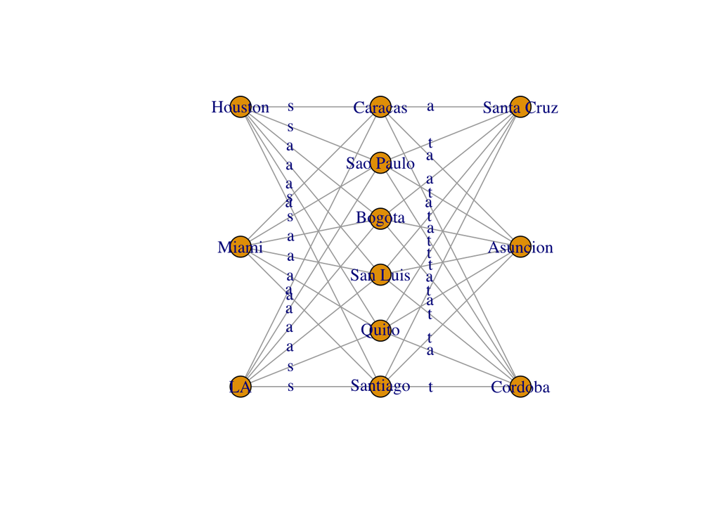

```r
# Make graph by setting 7 nodes/vertices, edges from nodes/vertices and distances from data matrix
g <- add_edges(make_empty_graph(n = 12, directed = FALSE),
               t(data[, 1:2]), weight=data[,3]) %>%

  # Set vertice/node names
  set_vertex_attr("name", value = c("Houston","Miami","LA","Caracas","Sao Paulo","Bogota","San Luis", "Quito","Santiago","Santa Cruz","Asuncion","Cordoba"))

# Set coordinates so looks similar to book diagram
  ## This is just for visualization, but could include it in data file
# add coordinates so that it is connected the way you want it
g$layout <- matrix(c(-1550,-1550, -1550,  0, 0, 0, 0, 0, 0, 1550,1550, 1550,
                     500, 250, 0, 500,400,300,200,100,0,500, 250, 0), nc = 2)
label <- c("s", "s", "a", "a", "a","a","s","s","a","a","a","a","a","a","a","a","s","s","a", "t","a","t","t","t","a","t","a","t","a","t","a","t","a","t","a","t","a","t","a","t")

# Lable edges with the distance or weight
#E(g)$label <- nw2[, 3]
E(g)$label <- label
plot(g)
```

### Problem 2:

```r
p2 <- make.lp(0, 36)
lp.control(p2, sense = "min")

obj_fn <- data$hours

set.objfn(p2, obj_fn)


# constraints to require stopping in a staging city
# 1-6: Houston
# 7-12: Miami
# 13 - 18: LA
add.constraint(p2, c(1,1,1,1,1,1,1,1,1,1,1,1,1,1,1,1,1,1,0,0,0,0,0,0,0,0,0,0,0,0,0,0,0,0,0,0), ">=", 1)

# All constraints for each staging city to Bolivia (Santa Cruz)
add.constraint(p2, c(-1,0,0,0,0,0,-1,0,0,0,0,0,-1,0,0,0,0,0,1,0,0,0,0,0,0,0,0,0,0,0,0,0,0,0,0,0), "<=", 0 )
add.constraint(p2, c(0,-1,0,0,0,0,0,-1,0,0,0,0,0,-1,0,0,0,0,0,1,0,0,0,0,0,0,0,0,0,0,0,0,0,0,0,0), "<=", 0 )
add.constraint(p2, c(0,0,-1,0,0,0,0,0,-1,0,0,0,0,0,-1,0,0,0,0,0,1,0,0,0,0,0,0,0,0,0,0,0,0,0,0,0), "<=", 0 )
add.constraint(p2, c(0,0,0,-1,0,0,0,0,0,-1,0,0,0,0,0,-1,0,0,0,0,0,1,0,0,0,0,0,0,0,0,0,0,0,0,0,0), "<=", 0 )
add.constraint(p2, c(0,0,0,0,-1,0,0,0,0,0,-1,0,0,0,0,0,-1,0,0,0,0,0,1,0,0,0,0,0,0,0,0,0,0,0,0,0), "<=", 0 )
add.constraint(p2, c(0,0,0,0,0,-1,0,0,0,0,0,-1,0,0,0,0,0,-1,0,0,0,0,0,1,0,0,0,0,0,0,0,0,0,0,0,0), "<=", 0 )

# All constraints for each staging city to Paraguay (Asuncion)
add.constraint(p2, c(-1,0,0,0,0,0,-1,0,0,0,0,0,-1,0,0,0,0,0,0,0,0,0,0,0,1,0,0,0,0,0,0,0,0,0,0,0), "<=", 0 )
add.constraint(p2, c(0,-1,0,0,0,0,0,-1,0,0,0,0,0,-1,0,0,0,0,0,0,0,0,0,0,0,1,0,0,0,0,0,0,0,0,0,0), "<=", 0 )
add.constraint(p2, c(0,0,-1,0,0,0,0,0,-1,0,0,0,0,0,-1,0,0,0,0,0,0,0,0,0,0,0,1,0,0,0,0,0,0,0,0,0), "<=", 0 )
add.constraint(p2, c(0,0,0,-1,0,0,0,0,0,-1,0,0,0,0,0,-1,0,0,0,0,0,0,0,0,0,0,0,1,0,0,0,0,0,0,0,0), "<=", 0 )
add.constraint(p2, c(0,0,0,0,-1,0,0,0,0,0,-1,0,0,0,0,0,-1,0,0,0,0,0,0,0,0,0,0,0,1,0,0,0,0,0,0,0), "<=", 0 )
add.constraint(p2, c(0,0,0,0,0,-1,0,0,0,0,0,-1,0,0,0,0,0,-1,0,0,0,0,0,0,0,0,0,0,0,1,0,0,0,0,0,0), "<=", 0 )

# All constraints for each staging city to Argentina (Cordoba)
add.constraint(p2, c(-1,0,0,0,0,0,-1,0,0,0,0,0,-1,0,0,0,0,0,0,0,0,0,0,0,0,0,0,0,0,0,1,0,0,0,0,0), "<=", 0 )
add.constraint(p2, c(0,-1,0,0,0,0,0,-1,0,0,0,0,0,-1,0,0,0,0,0,0,0,0,0,0,0,0,0,0,0,0,0,1,0,0,0,0), "<=", 0 )
add.constraint(p2, c(0,0,-1,0,0,0,0,0,-1,0,0,0,0,0,-1,0,0,0,0,0,0,0,0,0,0,0,0,0,0,0,0,0,1,0,0,0), "<=", 0 )
add.constraint(p2, c(0,0,0,-1,0,0,0,0,0,-1,0,0,0,0,0,-1,0,0,0,0,0,0,0,0,0,0,0,0,0,0,0,0,0,1,0,0), "<=", 0 )
add.constraint(p2, c(0,0,0,0,-1,0,0,0,0,0,-1,0,0,0,0,0,-1,0,0,0,0,0,0,0,0,0,0,0,0,0,0,0,0,0,1,0), "<=", 0 )
add.constraint(p2, c(0,0,0,0,0,-1,0,0,0,0,0,-1,0,0,0,0,0,-1,0,0,0,0,0,0,0,0,0,0,0,0,0,0,0,0,0,1), "<=", 0 )

# constraints to require landing in all 3 of the high impact cities
add.constraint(p2, c(0,0,0,0,0,0,0,0,0,0,0,0,0,0,0,0,0,0,1,1,1,1,1,1,0,0,0,0,0,0,0,0,0,0,0,0), "=", 1 ) # Bolivia
add.constraint(p2, c(0,0,0,0,0,0,0,0,0,0,0,0,0,0,0,0,0,0,0,0,0,0,0,0,1,1,1,1,1,1,0,0,0,0,0,0), "=", 1 ) # Paraguay
add.constraint(p2, c(0,0,0,0,0,0,0,0,0,0,0,0,0,0,0,0,0,0,0,0,0,0,0,0,0,0,0,0,0,0,1,1,1,1,1,1), "=", 1 ) # Cordoba

#Convert to binary
set.type(p2, 1:36, "binary")

solve(p2)

solution_table2 = matrix(get.variables(p2), nrow=6,byrow = T)
colnames(solution_table2) = c("Caracas","Sao Paulo","Bogota","San Luis","Quito", "Santiago")
rownames(solution_table2) =  c("Houston","Miami","Los Angeles","Santa Cruz","Asuncion","Cordoba")
```

```r
print(solution_table2)
```

```
##             Caracas Sao Paulo Bogota San Luis Quito Santiago
## Houston           0         0      0        0     0        0
## Miami             0         0      1        0     0        0
## Los Angeles       0         0      0        0     0        0
## Santa Cruz        0         0      1        0     0        0
## Asuncion          0         0      1        0     0        0
## Cordoba           0         0      1        0     0        0
```

If 3 planes leave Miami at the same time, stop to refuel in Bogota and leave for the 3 high-impact cities it will take: 20.35 hours.

#### Shortest path

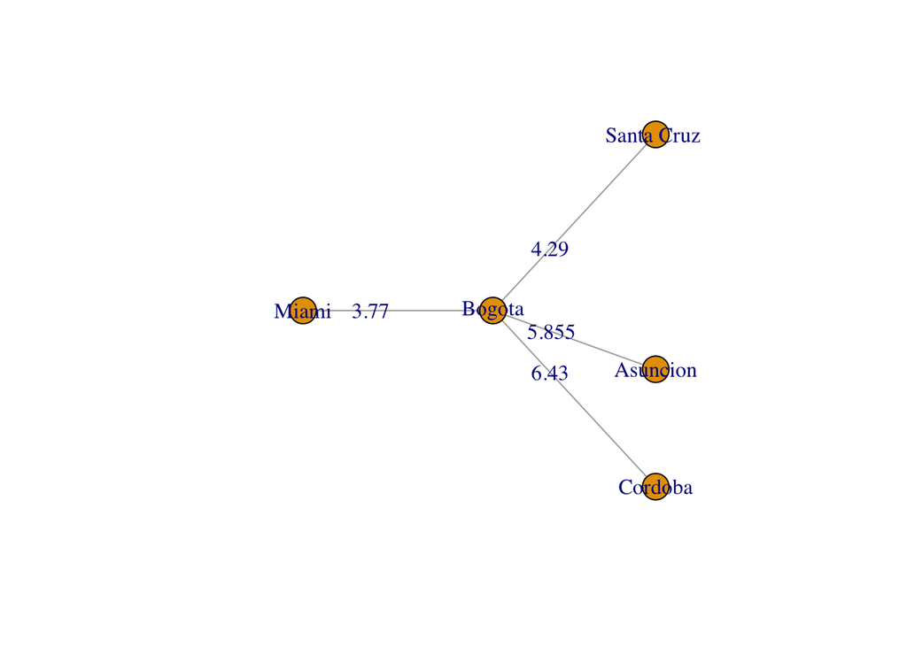

```r
dig2 <- matrix(nc = 3, byrow = TRUE,
              c(1, 2, 3.77,
                2, 3, 4.29,
                2, 4, 5.855,
                2, 5, 6.43))
gg2 <- add_edges(make_empty_graph(n = 5, directed = FALSE),
               t(dig2[, 1:2]), weight=dig2[,3]) %>%
  set_vertex_attr("name", value = c("Miami","Bogota","Santa Cruz ","Asuncion","Cordoba"))

# Set coordinates so looks similar to book diagram
  ## This is just for visualization, but could include it in data file
gg2$layout <- matrix(c(-350,0, 300,  300,  300,
                     100,100, 400, 0, -200), nc = 2)
E(gg2)$label <- dig2[, 3]
plot(gg2)
```

Breaking down the diagram, each city shown above should:

- Spend 3.77 hours going from Miami to Bogota, Colombia.
- Spend 4.29 hours going from Bogota, Colombia to Santa Cruz, Bolivia.
- Spend 5.855 hours going from Bogota, Colombia to Asuncion, Paraguay.
- Spend 6.43 hours going from Bogota, Colombia to Cordoba, Argentina

Bottlenecks:  
See below for the longest timed route.

```r
p2 <- make.lp(0, 36)
lp.control(p2, sense = "max")

obj_fn <- data$hours

set.objfn(p2, obj_fn)


# constraints to require stopping in a staging city
# 1-6: Houston
# 7-12: Miami
# 13 - 18: LA
add.constraint(p2, c(1,1,1,1,1,1,1,1,1,1,1,1,1,1,1,1,1,1,0,0,0,0,0,0,0,0,0,0,0,0,0,0,0,0,0,0), ">=", 1)

# All constraints for each staging city to Bolivia (Santa Cruz)
add.constraint(p2, c(-1,0,0,0,0,0,-1,0,0,0,0,0,-1,0,0,0,0,0,1,0,0,0,0,0,0,0,0,0,0,0,0,0,0,0,0,0), "<=", 0 )
add.constraint(p2, c(0,-1,0,0,0,0,0,-1,0,0,0,0,0,-1,0,0,0,0,0,1,0,0,0,0,0,0,0,0,0,0,0,0,0,0,0,0), "<=", 0 )
add.constraint(p2, c(0,0,-1,0,0,0,0,0,-1,0,0,0,0,0,-1,0,0,0,0,0,1,0,0,0,0,0,0,0,0,0,0,0,0,0,0,0), "<=", 0 )
add.constraint(p2, c(0,0,0,-1,0,0,0,0,0,-1,0,0,0,0,0,-1,0,0,0,0,0,1,0,0,0,0,0,0,0,0,0,0,0,0,0,0), "<=", 0 )
add.constraint(p2, c(0,0,0,0,-1,0,0,0,0,0,-1,0,0,0,0,0,-1,0,0,0,0,0,1,0,0,0,0,0,0,0,0,0,0,0,0,0), "<=", 0 )
add.constraint(p2, c(0,0,0,0,0,-1,0,0,0,0,0,-1,0,0,0,0,0,-1,0,0,0,0,0,1,0,0,0,0,0,0,0,0,0,0,0,0), "<=", 0 )

# All constraints for each staging city to Paraguay (Asuncion)
add.constraint(p2, c(-1,0,0,0,0,0,-1,0,0,0,0,0,-1,0,0,0,0,0,0,0,0,0,0,0,1,0,0,0,0,0,0,0,0,0,0,0), "<=", 0 )
add.constraint(p2, c(0,-1,0,0,0,0,0,-1,0,0,0,0,0,-1,0,0,0,0,0,0,0,0,0,0,0,1,0,0,0,0,0,0,0,0,0,0), "<=", 0 )
add.constraint(p2, c(0,0,-1,0,0,0,0,0,-1,0,0,0,0,0,-1,0,0,0,0,0,0,0,0,0,0,0,1,0,0,0,0,0,0,0,0,0), "<=", 0 )
add.constraint(p2, c(0,0,0,-1,0,0,0,0,0,-1,0,0,0,0,0,-1,0,0,0,0,0,0,0,0,0,0,0,1,0,0,0,0,0,0,0,0), "<=", 0 )
add.constraint(p2, c(0,0,0,0,-1,0,0,0,0,0,-1,0,0,0,0,0,-1,0,0,0,0,0,0,0,0,0,0,0,1,0,0,0,0,0,0,0), "<=", 0 )
add.constraint(p2, c(0,0,0,0,0,-1,0,0,0,0,0,-1,0,0,0,0,0,-1,0,0,0,0,0,0,0,0,0,0,0,1,0,0,0,0,0,0), "<=", 0 )

# All constraints for each staging city to Argentina (Cordoba)
add.constraint(p2, c(-1,0,0,0,0,0,-1,0,0,0,0,0,-1,0,0,0,0,0,0,0,0,0,0,0,0,0,0,0,0,0,1,0,0,0,0,0), "<=", 0 )
add.constraint(p2, c(0,-1,0,0,0,0,0,-1,0,0,0,0,0,-1,0,0,0,0,0,0,0,0,0,0,0,0,0,0,0,0,0,1,0,0,0,0), "<=", 0 )
add.constraint(p2, c(0,0,-1,0,0,0,0,0,-1,0,0,0,0,0,-1,0,0,0,0,0,0,0,0,0,0,0,0,0,0,0,0,0,1,0,0,0), "<=", 0 )
add.constraint(p2, c(0,0,0,-1,0,0,0,0,0,-1,0,0,0,0,0,-1,0,0,0,0,0,0,0,0,0,0,0,0,0,0,0,0,0,1,0,0), "<=", 0 )
add.constraint(p2, c(0,0,0,0,-1,0,0,0,0,0,-1,0,0,0,0,0,-1,0,0,0,0,0,0,0,0,0,0,0,0,0,0,0,0,0,1,0), "<=", 0 )
add.constraint(p2, c(0,0,0,0,0,-1,0,0,0,0,0,-1,0,0,0,0,0,-1,0,0,0,0,0,0,0,0,0,0,0,0,0,0,0,0,0,1), "<=", 0 )

# constraints to require landing in all 3 of the high impact cities
add.constraint(p2, c(0,0,0,0,0,0,0,0,0,0,0,0,0,0,0,0,0,0,1,1,1,1,1,1,0,0,0,0,0,0,0,0,0,0,0,0), "=", 1 ) # Bolivia
add.constraint(p2, c(0,0,0,0,0,0,0,0,0,0,0,0,0,0,0,0,0,0,0,0,0,0,0,0,1,1,1,1,1,1,0,0,0,0,0,0), "=", 1 ) # Paraguay
add.constraint(p2, c(0,0,0,0,0,0,0,0,0,0,0,0,0,0,0,0,0,0,0,0,0,0,0,0,0,0,0,0,0,0,1,1,1,1,1,1), "=", 1 ) # Cordoba

#Convert to binary
set.type(p2, 1:36, "binary")

solve(p2)

solution_table_m = matrix(get.variables(p2), nrow=6,byrow = T)
colnames(solution_table_m) = c("Caracas","Sao Paulo","Bogota","San Luis","Quito", "Santiago")
rownames(solution_table_m) =  c("Houston","Miami","Los Angeles","Santa Cruz","Asuncion","Cordoba")
```

```r
print(solution_table_m)
```

```
##             Caracas Sao Paulo Bogota San Luis Quito Santiago
## Houston           1         1      1        1     1        1
## Miami             1         1      1        1     1        1
## Los Angeles       1         1      1        1     1        1
## Santa Cruz        0         0      0        0     1        0
## Asuncion          0         0      0        0     0        1
## Cordoba           0         1      0        0     0        0
```

Totaling to 988.42 of traveling hours. We see that inventory is leaving out of all three U.S. cities to the six staging cities and then to the three severely impacted cities. However, there are three staging cities (Caracas, Bogota, San Luis) that do not deliver inventory to the severely impacted cities, making it very inconvenient and adds to the overall time.

### Problem 3

```r
p3 <- make.lp(0, 36)
lp.control(p3, sense = "min")

# Set objective fn
obj_fn3 <- data$cost_ton
set.objfn(p3, obj_fn3)

# city1 constraints
add.constraint(p3, c(  1, 1, 1, 1, 1, 1,
                       0, 0, 0, 0, 0, 0,
                       0, 0, 0, 0, 0, 0,
                       0, 0, 0, 0, 0, 0,
                       0, 0, 0, 0, 0, 0,
                       0, 0, 0, 0, 0, 0), "<=",  1000000)

# city2 constraints     4, 5, 6, 7, 8, 9
add.constraint(p3, c(   0, 0, 0, 0, 0, 0,
                        1, 1, 1, 1, 1, 1,
                        0, 0, 0, 0, 0, 0,
                        0, 0, 0, 0, 0, 0,
                        0, 0, 0, 0, 0, 0,
                        0, 0, 0, 0, 0, 0), "<=",  750000)

# city3 constraints     4, 5, 6, 7, 8, 9
add.constraint(p3, c(   0, 0, 0, 0, 0, 0,
                        0, 0, 0, 0, 0, 0,
                        1, 1, 1, 1, 1, 1,
                        0, 0, 0, 0, 0, 0,
                        0, 0, 0, 0, 0, 0,
                        0, 0, 0, 0, 0, 0), "<=",  500000)

# city4 constraints     4, 5, 6, 7, 8, 9
add.constraint(p3, c(   -1, 0, 0, 0, 0, 0,
                        -1, 0, 0, 0, 0, 0,
                        -1, 0, 0, 0, 0, 0,
                        1, 0, 0, 0, 0, 0,
                        1, 0, 0, 0, 0, 0,
                        1, 0, 0, 0, 0, 0), "=",  -300000)

# city5 constraints     4, 5, 6, 7, 8, 9
add.constraint(p3, c(   0, -1, 0, 0, 0, 0,
                        0, -1, 0, 0, 0, 0,
                        0, -1, 0, 0, 0, 0,
                        0, 1, 0, 0, 0, 0,
                        0, 1, 0, 0, 0, 0,
                        0, 1, 0, 0, 0, 0), "=",  -240000)

# city6 constraints     4, 5, 6, 7, 8, 9
add.constraint(p3, c(   0, 0, -1, 0, 0, 0,
                        0, 0, -1, 0, 0, 0,
                        0, 0, -1, 0, 0, 0,
                        0, 0, 1, 0, 0, 0,
                        0, 0, 1, 0, 0, 0,
                        0, 0, 1, 0, 0, 0), "=", -200000 )

# city7 constraints     4, 5, 6, 7, 8, 9
add.constraint(p3, c(   0, 0, 0, -1, 0, 0,
                        0, 0, 0, -1, 0, 0,
                        0, 0, 0, -1, 0, 0,
                        0, 0, 0, 1, 0, 0,
                        0, 0, 0, 1, 0, 0,
                        0, 0, 0, 1, 0, 0), "=",  -180000)

# city8 constraints     4, 5, 6, 7, 8, 9
add.constraint(p3, c(   0, 0, 0, 0, -1, 0,
                        0, 0, 0, 0, -1, 0,
                        0, 0, 0, 0, -1, 0,
                        0, 0, 0, 0, 1, 0,
                        0, 0, 0, 0, 1, 0,
                        0, 0, 0, 0, 1, 0), "=",  -240000)

# city9 constraints     4, 5, 6, 7, 8, 9
add.constraint(p3, c(   0, 0, 0, 0, 0, -1,
                        0, 0, 0, 0, 0, -1,
                        0, 0, 0, 0, 0, -1,
                        0, 0, 0, 0, 0, 1,
                        0, 0, 0, 0, 0, 1,
                        0, 0, 0, 0, 0, 1), "=", -380000 )

# city10 constraints     4, 5, 6, 7, 8, 9
add.constraint(p3, c(   0, 0, 0, 0, 0, 0,
                        0, 0, 0, 0, 0, 0,
                        0, 0, 0, 0, 0, 0,
                        -1, -1, -1, -1, -1, -1,
                        0, 0, 0, 0, 0, 0,
                        0, 0, 0, 0, 0, 0), "=",  -150000)

# city11 constraints     4, 5, 6, 7, 8, 9
add.constraint(p3, c(   0, 0, 0, 0, 0, 0,
                        0, 0, 0, 0, 0, 0,
                        0, 0, 0, 0, 0, 0,
                        0, 0, 0, 0, 0, 0,
                        -1, 0, -1, 0, -1, 0,
                        0, 0, 0, 0, 0, 0), "=",  -120000)

# city12 constraints     4, 5, 6, 7, 8, 9
add.constraint(p3, c(   0, 0, 0, 0, 0, 0,
                        0, 0, 0, 0, 0, 0,
                        0, 0, 0, 0, 0, 0,
                        0, 0, 0, 0, 0, 0,
                        0, 0, 0, 0, 0, 0,
                        -1, -1, -1, -1, -1, -1), "=",  -180000)


# city4 to city 12 constraints
# only 500 total flights allowed
#                       4, 5, 6, 7, 8, 9
add.constraint(p3, c(   0, 0, 0, 0, 0, 0,
                        0, 0, 0, 0, 0, 0,
                        0, 0, 0, 0, 0, 0,
                        0, 0, 0, 0, 0, 0,
                        0, 0, 0, 0, 0, 0,
                        1, 0, 0, 0, 0, 0), "<=",  75000) # caracas to corodoba by air

# city6 to city12 constraints
# only 500 total flights allowed
#                       4, 5, 6, 7, 8, 9
add.constraint(p3, c(   0, 0, 0, 0, 0, 0,
                        0, 0, 0, 0, 0, 0,
                        0, 0, 0, 0, 0, 0,
                        0, 0, 0, 0, 0, 0,
                        0, 0, 0, 0, 0, 0,
                        0, 0, 1, 0, 0, 0), "<=",  75000) #bogota to corodoba by air

# city10 constraints
# only 200 total flights allowed
#                       4, 5, 6, 7, 8, 9
add.constraint(p3, c(   0, 0, 0, 0, 0, 0,
                        0, 0, 0, 0, 0, 0,
                        0, 0, 0, 0, 0, 0,
                        1, 0, 1, 0, 0, 0, #caracas to santa cruz by air, bogota to santa cruz by air
                        0, 0, 0, 0, 0, 0,
                        0, 0, 0, 0, 0, 0), "<=",  30000)

# city3 to city8 to city10
# ship in, truck out
#                       4, 5, 6, 7, 8, 9
add.constraint(p3, c(   0, 0, 0, 0, 0, 0,
                        0, 0, 0, 0, 0, 0,
                        0, 0, 0, 0, -1, 0, # Only instance where supplies arrive in quito via ship
                        0, 0, 0, 0, 1, 0, # Only instance where supplies leave quito via truck
                        0, 0, 0, 0, 0, 0,
                        0, 0, 0, 0, 0, 0), "<=",  0)


# Solve the model
solve(p3)
```

```r
solution_table3 = matrix(get.variables(p3), nrow=6,byrow = T)
colnames(solution_table3) = c("Caracas","Sao Paulo","Bogota","San Luis","Quito", "Santiago")
rownames(solution_table3) =  c("Houston","Miami","Los Angeles","Santa Cruz","Asuncion","Cordoba")
solution_table3 <- data.frame(solution_table3)
print(solution_table3)
```

```
##             Caracas Sao.Paulo Bogota San.Luis  Quito Santiago
## Houston           0    240000 275000   180000 270000        0
## Miami        525000         0      0        0      0        0
## Los Angeles       0         0      0        0 120000   380000
## Santa Cruz    30000         0      0        0 120000        0
## Asuncion     120000         0      0        0      0        0
## Cordoba       75000         0  75000        0  30000        0
```

```r
get.objective(p3)
```

```
## [1] 397313250
```

**Bottleneck:**

- Houston and Miami have 35,000 and 225,000 tons unused respectively. Los Angeles uses its entire supply and presents the least expensive routes to both Quito and Santiago. Because the Los Angeles to Santiago route is $127.50 less expensive than the next most cost-effective alternative all 380,000 tons of demand are used. This causes Los Angeles to only have 120,000 additional tons to supply Quito at $70.83 per which has a demand of 240,000, the additional 120,000 plus 150,000 for high impact cities must come from Houston at $160 per ton. If we can increase the supply of Los Angeles by 120,000 tons of the 225,000 unused, we will realize cost savings of $10.7 million. If we increase the supply of Los Angeles to accommodate the full amount sent to Quito (390,000 tons) we will realize cost savings of over $24 million for the route. The route from Los Angeles to Quito is also via ship, so all units are available to be trucked to other destinations.
- If all 390,000 tons are available to be shipped from Los Angeles to Quito it will have additional cost savings in satisfying the demand requirements of Santa Cruz. Currently we fly 30,000 tons from Caracas to Santa Cruz at $226.67 per ton and drive 120,000 from Quito at $112.99. If we utilize the Quito to Santa Cruz truck route we would see savings of $3.4 million.
- We should also confirm that Cordoba has a separate limit of 500 flights from Caracas and Bogota because if we could re-allocate the 500 flights from Caracas to Bogota, we would save $6 million on this route. In the bigger picture this is not a wise approach because the lowest cost per ton from a US city to Bogota is $240 and the shipments from Miami to Caracas are only $54.17.

### Problem 4

```r
p4 <- make.lp(0, 36)
lp.control(p4, sense = "max")

# Set objective fn
obj_fn4 <- data$tons
set.objfn(p4, obj_fn4)

# city1 constraints
add.constraint(p4, c(  1, 1, 1, 1, 1, 1,
                       0, 0, 0, 0, 0, 0,
                       0, 0, 0, 0, 0, 0,
                       0, 0, 0, 0, 0, 0,
                       0, 0, 0, 0, 0, 0,
                       0, 0, 0, 0, 0, 0), "<=",  1000000)

# city2 constraints     4, 5, 6, 7, 8, 9
add.constraint(p4, c(   0, 0, 0, 0, 0, 0,
                        1, 1, 1, 1, 1, 1,
                        0, 0, 0, 0, 0, 0,
                        0, 0, 0, 0, 0, 0,
                        0, 0, 0, 0, 0, 0,
                        0, 0, 0, 0, 0, 0), "<=",  750000)

# city3 constraints     4, 5, 6, 7, 8, 9
add.constraint(p4, c(   0, 0, 0, 0, 0, 0,
                        0, 0, 0, 0, 0, 0,
                        1, 1, 1, 1, 1, 1,
                        0, 0, 0, 0, 0, 0,
                        0, 0, 0, 0, 0, 0,
                        0, 0, 0, 0, 0, 0), "<=",  500000)

# city4 constraints     4, 5, 6, 7, 8, 9
add.constraint(p4, c(   -1, 0, 0, 0, 0, 0,
                        -1, 0, 0, 0, 0, 0,
                        -1, 0, 0, 0, 0, 0,
                        1, 0, 0, 0, 0, 0,
                        1, 0, 0, 0, 0, 0,
                        1, 0, 0, 0, 0, 0), ">=",  -300000)

# city5 constraints     4, 5, 6, 7, 8, 9
add.constraint(p4, c(   0, -1, 0, 0, 0, 0,
                        0, -1, 0, 0, 0, 0,
                        0, -1, 0, 0, 0, 0,
                        0, 1, 0, 0, 0, 0,
                        0, 1, 0, 0, 0, 0,
                        0, 1, 0, 0, 0, 0), ">=",  -240000)

# city6 constraints     4, 5, 6, 7, 8, 9
add.constraint(p4, c(   0, 0, -1, 0, 0, 0,
                        0, 0, -1, 0, 0, 0,
                        0, 0, -1, 0, 0, 0,
                        0, 0, 1, 0, 0, 0,
                        0, 0, 1, 0, 0, 0,
                        0, 0, 1, 0, 0, 0), ">=", -200000 )

# city7 constraints     4, 5, 6, 7, 8, 9
add.constraint(p4, c(   0, 0, 0, -1, 0, 0,
                        0, 0, 0, -1, 0, 0,
                        0, 0, 0, -1, 0, 0,
                        0, 0, 0, 1, 0, 0,
                        0, 0, 0, 1, 0, 0,
                        0, 0, 0, 1, 0, 0), ">=",  -180000)

# city8 constraints     4, 5, 6, 7, 8, 9
add.constraint(p4, c(   0, 0, 0, 0, -1, 0,
                        0, 0, 0, 0, -1, 0,
                        0, 0, 0, 0, -1, 0,
                        0, 0, 0, 0, 1, 0,
                        0, 0, 0, 0, 1, 0,
                        0, 0, 0, 0, 1, 0), ">=",  -240000)

# city9 constraints     4, 5, 6, 7, 8, 9
add.constraint(p4, c(   0, 0, 0, 0, 0, -1,
                        0, 0, 0, 0, 0, -1,
                        0, 0, 0, 0, 0, -1,
                        0, 0, 0, 0, 0, 1,
                        0, 0, 0, 0, 0, 1,
                        0, 0, 0, 0, 0, 1), ">=", -380000 )

# city10 constraints     4, 5, 6, 7, 8, 9
add.constraint(p4, c(   0, 0, 0, 0, 0, 0,
                        0, 0, 0, 0, 0, 0,
                        0, 0, 0, 0, 0, 0,
                        -1, -1, -1, -1, -1, -1,
                        0, 0, 0, 0, 0, 0,
                        0, 0, 0, 0, 0, 0), ">=",  -150000)

# city11 constraints     4, 5, 6, 7, 8, 9
add.constraint(p4, c(   0, 0, 0, 0, 0, 0,
                        0, 0, 0, 0, 0, 0,
                        0, 0, 0, 0, 0, 0,
                        0, 0, 0, 0, 0, 0,
                        -1, -1, -1, -1, -1, -1,
                        0, 0, 0, 0, 0, 0), ">=",  -120000)

# city12 constraints     4, 5, 6, 7, 8, 9
add.constraint(p4, c(   0, 0, 0, 0, 0, 0,
                        0, 0, 0, 0, 0, 0,
                        0, 0, 0, 0, 0, 0,
                        0, 0, 0, 0, 0, 0,
                        0, 0, 0, 0, 0, 0,
                        -1, -1, -1, -1, -1, -1), ">=",  -180000)

# City4 Air restrictions
#                       4, 5, 6, 7, 8, 9
add.constraint(p4, c(   0, 0, 0, 0, 0, 0,
                        0, 0, 0, 0, 0, 0,
                        1, 0, 0, 0, 0, 0,
                        0, 0, 0, 0, 0, 0,
                        0, 0, 0, 0, 0, 0,
                        0, 0, 0, 0, 0, 0), "<=",  45000)

# City5 Air restrictions
#                       4, 5, 6, 7, 8, 9
add.constraint(p4, c(   0, 0, 0, 0, 0, 0,
                        0, 0, 0, 0, 0, 0,
                        0, 1, 0, 0, 0, 0,
                        0, 0, 0, 0, 0, 0,
                        0, 0, 0, 0, 0, 0,
                        0, 0, 0, 0, 0, 0), "<=",  37500)

# City6 Air restrictions
#                       4, 5, 6, 7, 8, 9
add.constraint(p4, c(   0, 0, 1, 0, 0, 0,
                        0, 0, 1, 0, 0, 0,
                        0, 0, 1, 0, 0, 0,
                        0, 0, 0, 0, 0, 0,
                        0, 0, 0, 0, 0, 0,
                        0, 0, 0, 0, 0, 0), "<=",  105000)


# City7 Air restrictions
#                       4, 5, 6, 7, 8, 9
add.constraint(p4, c(   0, 0, 0, 1, 0, 0,
                        0, 0, 0, 1, 0, 0,
                        0, 0, 0, 1, 0, 0,
                        0, 0, 0, 0, 0, 0,
                        0, 0, 0, 0, 0, 0,
                        0, 0, 0, 0, 0, 0), "<=",  120000)

# City8 Air restrictions
#                       4, 5, 6, 7, 8, 9
add.constraint(p4, c(   0, 0, 0, 0, 1, 0,
                        0, 0, 0, 0, 1, 0,
                        0, 0, 0, 0, 0, 0,
                        0, 0, 0, 0, 0, 0,
                        0, 0, 0, 0, 0, 0,
                        0, 0, 0, 0, 0, 0), "<=",  135000)

# City9 Air restrictions
#                       4, 5, 6, 7, 8, 9
add.constraint(p4, c(   0, 0, 0, 0, 0, 1,
                        0, 0, 0, 0, 0, 1,
                        0, 0, 0, 0, 0, 0,
                        0, 0, 0, 0, 0, 0,
                        0, 0, 0, 0, 0, 0,
                        0, 0, 0, 0, 0, 0), "<=",  90000)


# city10 air restrictions
#                       4, 5, 6, 7, 8, 9
add.constraint(p4, c(   0, 0, 0, 0, 0, 0,
                        0, 0, 0, 0, 0, 0,
                        0, 0, 0, 0, 0, 0,
                        1, 0, 1, 0, 0, 0, #
                        0, 0, 0, 0, 0, 0,
                        0, 0, 0, 0, 0, 0), "<=",  67500)

# city11 air restrictions
#                       4, 5, 6, 7, 8, 9
add.constraint(p4, c(   0, 0, 0, 0, 0, 0,
                        0, 0, 0, 0, 0, 0,
                        0, 0, 0, 0, 0, 0,
                        0, 0, 0, 0, 0, 0,
                        1, 0, 1, 0, 1, 0,
                        0, 0, 0, 0, 0, 0), "<=",  105000)

# city12 air restrictions
#                       4, 5, 6, 7, 8, 9
add.constraint(p4, c(   0, 0, 0, 0, 0, 0,
                        0, 0, 0, 0, 0, 0,
                        0, 0, 0, 0, 0, 0,
                        0, 0, 0, 0, 0, 0,
                        0, 0, 0, 0, 0, 0,
                        1, 0, 1, 0, 1, 0), "<=",  165000)

# city4 to city 12 constraints question 3 air constraints
# only 500 total flights allowed
#                       4, 5, 6, 7, 8, 9
add.constraint(p4, c(   0, 0, 0, 0, 0, 0,
                        0, 0, 0, 0, 0, 0,
                        0, 0, 0, 0, 0, 0,
                        0, 0, 0, 0, 0, 0,
                        0, 0, 0, 0, 0, 0,
                        1, 0, 0, 0, 0, 0), "<=",  75000) # caracas to corodoba by air

# city6 to city12 constraints question 3 air constraints
# only 500 total flights allowed
#                       4, 5, 6, 7, 8, 9
add.constraint(p4, c(   0, 0, 0, 0, 0, 0,
                        0, 0, 0, 0, 0, 0,
                        0, 0, 0, 0, 0, 0,
                        0, 0, 0, 0, 0, 0,
                        0, 0, 0, 0, 0, 0,
                        0, 0, 1, 0, 0, 0), "<=",  75000) #bogota to corodoba by air


# city10 truck restrictions
#                       4, 5, 6, 7, 8, 9
add.constraint(p4, c(   0, 0, 0, 0, 0, 0,
                        0, 0, 0, 0, 0, 0,
                        0, 0, 0, 0, 0, 0,
                        0, 1, 0, 1, 1, 1,
                        0, 0, 0, 0, 0, 0,
                        0, 0, 0, 0, 0, 0), "<=",  15930)

# city11 truck restrictions
#                       4, 5, 6, 7, 8, 9
add.constraint(p4, c(   0, 0, 0, 0, 0, 0,
                        0, 0, 0, 0, 0, 0,
                        0, 0, 0, 0, 0, 0,
                        0, 0, 0, 0, 0, 0,
                        0, 1, 0, 1, 0, 1,
                        0, 0, 0, 0, 0, 0), "<=",  17700)

# city12 truck restrictions
#                       4, 5, 6, 7, 8, 9
add.constraint(p4, c(   0, 0, 0, 0, 0, 0,
                        0, 0, 0, 0, 0, 0,
                        0, 0, 0, 0, 0, 0,
                        0, 0, 0, 0, 0, 0,
                        0, 0, 0, 0, 0, 0,
                        0, 1, 0, 1, 0, 1), "<=",  21240)


# city3 to city8 to city10
# ship in, truck out
#                       4, 5, 6, 7, 8, 9
add.constraint(p4, c(   0, 0, 0, 0, 0, 0,
                        0, 0, 0, 0, 0, 0,
                        0, 0, 0, 0, -1, 0, # Only instance where supplies arrive in quito via ship
                        0, 0, 0, 0, 1, 0, # Only instance where supplies leave quito via truck
                        0, 0, 0, 0, 0, 0,
                        0, 0, 0, 0, 0, 0), "<=",  0)


# Solve the model
solve(p4)



get.objective(p4)
```

```r
solution_table4 = matrix(get.variables(p4), nrow=6,byrow = T)
colnames(solution_table4) = c("Caracas","Sao Paulo","Bogota","San Luis","Quito", "Santiago")
rownames(solution_table4) =  c("Houston","Miami","Los Angeles","Santa Cruz","Asuncion","Cordoba")
solution_table4 <- data.frame(solution_table4)
print(solution_table4)
```

```
##             Caracas Sao.Paulo Bogota San.Luis  Quito Santiago
## Houston      547500    285930      0   120000      0    46570
## Miami             0         0 105000        0 120000    43430
## Los Angeles       0         0      0        0 210000   290000
## Santa Cruz    67500     15930      0        0      0        0
## Asuncion     105000     15000      0        0      0        0
## Cordoba       75000     15000      0        0  90000        0
```

```r
# total tons of supplies shipped to South America
print(sum(solution_table4))
```

```
## [1] 2151860
```

To maximize supplies for all 9 South American cities the following steps should be taken:

- Use 2282 ships to transport 547500 tons of supplies from Houston to Caracas
- Use 1192 ships to transport 285930 tons of supplies from Houston to Sao Paulo
- Use 800 planes to transport 120000 tons of supplies from Houston to San Luis
- Use 310 planes to transport 46570 tons of supplies from Houston to Santiago
- Use 700 planes to transport 105000 tons of supplies from Miami to Bogota
- Use 800 planes to transport 120000 tons of supplies from Miami to Quito
- Use 290 planes to transport 43430 tons of supplies from Miami to Santiago
- Use 875 ships to transport 210000 tons of supplies from LA to Quito
- Use 1209 ships to transport 290000 tons of supplies from LA to Santiago
- Use 450 planes to transport 67500 tons of supplies from Caracas to Santa Cruz
- Use 900 trucks to transport 15930 tons of supplies from Sao Paulo to Santa Cruz
- Use 700 planes to transport 105000 tons of supplies from Caracas to Asuncion
- Use 848 trucks to transport 15000 tons of supplies from Sau Paulo to Asuncion
- Use 500 planes to transport 75000 tons of supplies from Caracas to Cordoba
- Use 848 trucks to transport 15000 tons of supplies from Sau Paulo to Cordoba
- Use 600 planes to transport 90000 tons of supplies from Quito to Cordoba

Demand requirements would be satisfied for the following staging cities: Caracas Sao Paulo, Quito, Santiago

Demand requirements would be satisfied for the following high-impact cities: Asuncion, Cordoba.

**Bottlenecks:**